# Getting Started with M&Ms

The steps to analyzing the M & M data are relatively straightforward but they do require you to use some very basic R functions as well as one additionally more advanced one. As this is the first time you’re loading, you don’t have anything in it. Consequently, the first thing to do is to load your data. If you are using Rstudio, your first step should be to create a Project (Go to File -> New Project). If you’ve already created a PEP 4400 folder for this class, then you’ll select “Use Existing Folder” and choose that folder. If you haven’t, then you can choose “Create New Directory” and place that folder any where you like.

**It is essential that ultimately your spreadsheet for the M & Ms is in that project folder.**

As long as you are in your project, you should be able to load your data.

```r
data <- read.csv("My MM data.csv", header = TRUE, sep = ",")
```

We can then look to verify that the data is there and that it is what we expect it to be.

```r
str(data)
```

```
'data.frame':   111 obs. of  3 variables:
 $ Color : Factor w/ 6 levels "BL","BR","G",..: 4 4 4 4 4 4 4 4 4 4 ...
 $ Defect: Factor w/ 4 levels "C","L","M","N": 2 2 2 2 2 1 4 4 4 4 ...
 $ Name  : Factor w/ 2 levels "Bag 1","Bag 2": 1 1 1 1 1 1 1 1 1 1 ...
```

You can see that we have a data frame (R’s term for a spread sheeet) with 3 columns name Color, Defect, and Name. You can see that these are “factors” (R’s term for categories) and that each column has a different number of levels.

We can use the table command to get a summary of our data. Table will simply count the number of rows belonging to unique factor levels. So for instance, if we want to know how many of each color there are in your group’s sample, we simply use the table function on the Color column of our data.

```r
table(data$Color)
```

```
BL BR  G  O  R  Y
 7 16 22 30 16 20
```

However, this isn’t very nice to look at. Though it tells us everything we want to know, the labels aren’t great. Luckily, we can do something about that. This time, we’re going to store our table as an object so that we can manipulate it further.

```r
mm.count <- table(data$Color)
  names(mm.count) <- c("blue", "brown", "green", "orange", "red", "yellow")
mm.count
```

```
  blue  brown  green orange    red yellow
     7     16     22     30     16     20
```

We’ve replaced the original names with the actual colors. This is much more appealing to look at. We can do the same thing with the defects

```r
defect.count <- table(data$Defect)
  names(defect.count) <- c("chipped", "letter", "multiple", "none")
defect.count
```

```
 chipped   letter multiple     none
       3       45        1       62
```

However, as we’ve mentioned, we are visual creatures. We prefer images over numbers as they appeal to our aesthetic sides. So, we can represent this data visually as well using a bar plot.

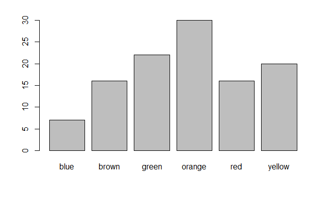

```r
barplot(mm.count)
```

Here we have a visual representation of the table we created for the colors showing the color on the x-axis and the height of each bar represents the number of M & Ms in that color. However, we can add some parameters to improve the way the plot looks.

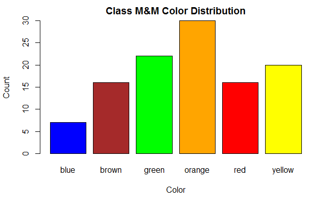

```r
barplot(mm.count,
        main = "Class M&M Color Distribution",
        xlab = "Color",
        ylab = "Count",
        col = names(mm.count))
```

And we can do the same thing with our defects

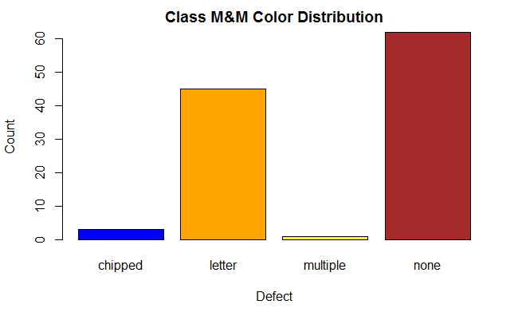

```r
barplot(defect.count, main = "Class M&M Color Distribution", xlab = "Defect",
        ylab = "Count", col = c("blue", "orange", "yellow", "brown"))
```

These barplots provide us with an absolute count of the numbers of M & Ms per category. However, it may be of interest to us to find the relative amounts to the whole. We can do this with a pie chart. The first step is to convert the numbers to percentages.

```r
color.percents <- round(mm.count/sum(mm.count)*100)
color.percents
```

```
  blue  brown  green orange    red yellow
     6     14     20     27     14     18
```

```r
defect.percents <- round(defect.count/sum(defect.count)*100)
defect.percents
```

```
 chipped   letter multiple     none
       3       41        1       56
```

Now that we have the percentages, we can create a pie chart to show the relative contributions to the whole.

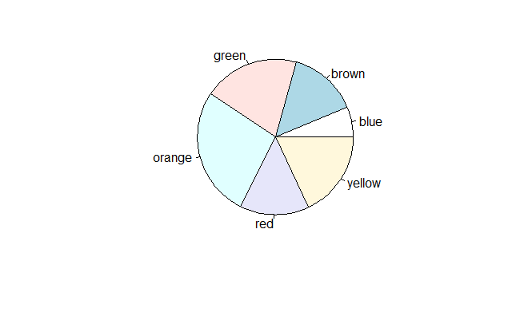

```r
pie(mm.count)
```

Again, shows us what we want, but not terribly aesthetically appealing, the colors don’t match the labels, and we have no way of visually judging how much of the pie each slice occupies. We can fix that.

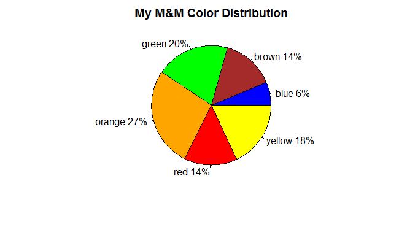

```r
color.labels <- paste(names(mm.count), " ", color.percents, "%", sep = "")
pie(mm.count, labels = color.labels, main = "My M&M Color Distribution",
    col = names(mm.count))
```

And we can do the same thing with the defects.

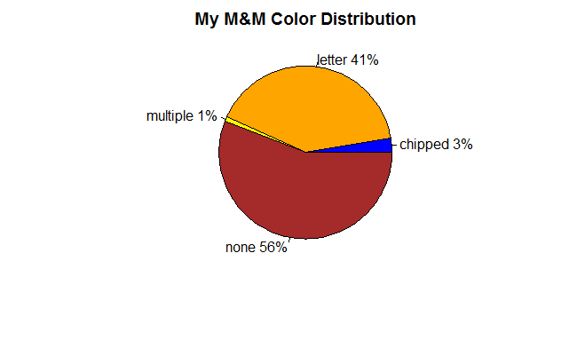

```r
defect.labels <- paste(names(defect.count), " ", defect.percents, "%", sep = "")
pie(defect.count, labels = defect.labels, main = "My M&M Color Distribution",
    col = c("blue", "orange", "yellow", "brown"))
```

We can also look at a contingency table. Contingency tables tell us about conditional situations. For example, a simple contingency table can tell us how many blue m&ms are chipped as compared to have a letter missing. Here is a simple contingency table.

```r
mm.ct <- table(data$Color, data$Defect)
mm.ct
```

```
      C  L  M  N
  BL  0  3  0  4
  BR  0  6  0 10
  G   0 13  0  9
  O   1 11  0 18
  R   2  4  1  9
  Y   0  8  0 12
```

We can also make contingency tables with a much greater amount of information. To do so, we need a custom package installed into R. Packages are simply collections of functions that aren’t part of the most basic R installation but which significantly extend the functionality. In this case, we need the gmodels package. It can be installed through the packages tab in Rstudio or with the following command

```r
install.packages("gmodels")
```

Once it installs, you then must load it.

```r
library(gmodels)
```

And now we can get our contingency table

```r
CrossTable(data$Color, data$Defect, prop.t = TRUE, prop.r = TRUE, prop.c = TRUE,
           prop.chisq = FALSE, chisq = FALSE)
```

```
   Cell Contents
|-------------------------|
|                       N |
|           N / Row Total |
|           N / Col Total |
|         N / Table Total |
|-------------------------|


Total Observations in Table:  111


             | data$Defect
  data$Color |         C |         L |         M |         N | Row Total |
-------------|-----------|-----------|-----------|-----------|-----------|
          BL |         0 |         3 |         0 |         4 |         7 |
             |     0.000 |     0.429 |     0.000 |     0.571 |     0.063 |
             |     0.000 |     0.067 |     0.000 |     0.065 |           |
             |     0.000 |     0.027 |     0.000 |     0.036 |           |
-------------|-----------|-----------|-----------|-----------|-----------|
          BR |         0 |         6 |         0 |        10 |        16 |
             |     0.000 |     0.375 |     0.000 |     0.625 |     0.144 |
             |     0.000 |     0.133 |     0.000 |     0.161 |           |
             |     0.000 |     0.054 |     0.000 |     0.090 |           |
-------------|-----------|-----------|-----------|-----------|-----------|
           G |         0 |        13 |         0 |         9 |        22 |
             |     0.000 |     0.591 |     0.000 |     0.409 |     0.198 |
             |     0.000 |     0.289 |     0.000 |     0.145 |           |
             |     0.000 |     0.117 |     0.000 |     0.081 |           |
-------------|-----------|-----------|-----------|-----------|-----------|
           O |         1 |        11 |         0 |        18 |        30 |
             |     0.033 |     0.367 |     0.000 |     0.600 |     0.270 |
             |     0.333 |     0.244 |     0.000 |     0.290 |           |
             |     0.009 |     0.099 |     0.000 |     0.162 |           |
-------------|-----------|-----------|-----------|-----------|-----------|
           R |         2 |         4 |         1 |         9 |        16 |
             |     0.125 |     0.250 |     0.062 |     0.562 |     0.144 |
             |     0.667 |     0.089 |     1.000 |     0.145 |           |
             |     0.018 |     0.036 |     0.009 |     0.081 |           |
-------------|-----------|-----------|-----------|-----------|-----------|
           Y |         0 |         8 |         0 |        12 |        20 |
             |     0.000 |     0.400 |     0.000 |     0.600 |     0.180 |
             |     0.000 |     0.178 |     0.000 |     0.194 |           |
             |     0.000 |     0.072 |     0.000 |     0.108 |           |
-------------|-----------|-----------|-----------|-----------|-----------|
Column Total |         3 |        45 |         1 |        62 |       111 |
             |     0.027 |     0.405 |     0.009 |     0.559 |           |
-------------|-----------|-----------|-----------|-----------|-----------|
```

The legend at the top tells you what each cell contains. In this case, we have the *n* or number of M & Ms meeting that criterion, the percentage of the row to which that cell belongs, the percentage of the column to which that cell belongs, and the percentage of the entire dataset. The margins (far right, bottom) give us the “marginal distributions”, or the numbers/percentages of each column or row out of the whole.

You now have enough information to make good headway on your M & M project